# Reproducible Reseach -Course Project #1

### Are there differences in activity patterns between weekdays and weekends?

First a new factor variable is created in the dataset with two levels - “weekday” and “weekend” indicating whether a given date is a weekday or weekend day.

```r
week <- weekdays(data_imputed$date)
for (i in 1:length(week)) {
    if ((week[i] == "lauantai") | (week[i] == "sunnuntai"))
    week[i] <- "weekend"  else  week[i] <- "weekday"
}
week <- as.factor(week)
summary(week)
```

```
## weekday weekend
##   12960    4608
```

```r
data_imputed$week <- week
data_imputed_weekday <- subset(data_imputed, week == "weekday")
data_imputed_weekend <- subset(data_imputed, week == "weekend")
```

Then the time series plots of the 5-minute interval (x-axis) and the average number of steps taken, averaged across all weekday days or weekend days (y-axis) are compared.

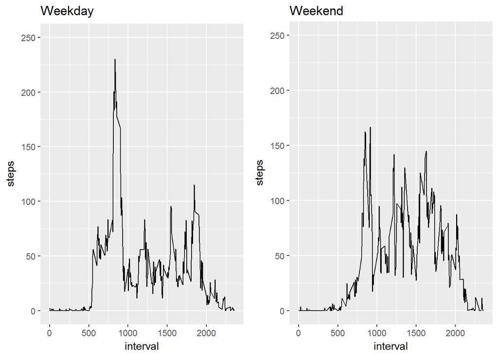

```r
steps_weekday <- aggregate(steps~interval,data_imputed_weekday,mean)
plot4 <- ggplot(data=steps_weekday,aes(interval,steps)) +geom_line() + ggtitle("Weekday") +ylim(0,250)
steps_weekend <- aggregate(steps~interval,data_imputed_weekend,mean)
plot5 <- ggplot(data=steps_weekend,aes(interval,steps)) +geom_line() + ggtitle("Weekend") +ylim(0,250)
grid.arrange(plot4,plot5, nrow=1)
```

Activity (step count) is more evenly dispersed during the weekends than during the weekdays.